# Broad Functions

Load libraries

```r
library(tidyverse)
library(dplyr)
library(readr)
library(reshape2)
library(ggforce)
library(vegan)
```

Load bin info

```r
bins_extendedinfo <- read_csv("~/Documents/UMich/papers/GrowthDefenseTradeOff/R output/bins_extendedinfo.csv")
```

Load metabolic enrichment results

```r
sigbins_enrichment <- read_delim("~/Documents/UMich/papers/GrowthDefenseTradeOff/anvio files//anvi_metabolism_output/metabolic_enrichment_output/sigbins_functional-enrichment-txt",
    delim = "\t", escape_double = FALSE,
    trim_ws = TRUE)
```

Load the module paths, hits, steps, and function info

```r
metab_modules <- read.table("~/Documents/UMich/papers/GrowthDefenseTradeOff/anvio files//anvi_metabolism_output/kegg-metabolism_modules.txt",sep="\t",header=T)
metab_modulesteps <- read.table("~/Documents/UMich/papers/GrowthDefenseTradeOff/anvio files//anvi_metabolism_output/kegg-metabolism_module_steps.txt",sep="\t",header=T)
metab_modulepaths <- read.table("~/Documents/UMich/papers/GrowthDefenseTradeOff/anvio files//anvi_metabolism_output/kegg-metabolism_module_paths.txt",sep="\t",header=T)
metab_hits <- read.table("~/Documents/UMich/papers/GrowthDefenseTradeOff/anvio files//anvi_metabolism_output/kegg-metabolism_hits.txt",sep="\t",header=T)
```

Combine dfs

```r
metab_modules_unique <- metab_modules %>%
  distinct(module, .keep_all = TRUE) %>%
  dplyr::rename(accession = module)

sigbins_combined <- merge(sigbins_enrichment, metab_modules_unique[c('accession', 'module_category', 'module_subcategory')], by = "accession", all.x = TRUE)
```

Rename the increase and decrease categories into resistant and susceptible categories.

```r
sigbins_combined <- sigbins_combined %>%
  mutate(associated_groups = ifelse(associated_groups == "increase", "resistant",
                                    ifelse(associated_groups == "decrease", "susceptible", associated_groups)))
```

Filter out modules that were enrichred significantly from the sigbins_combined

```r
sigmodules_sigmags <- sigbins_combined %>%
  filter(adjusted_q_value < 0.05)
```

This df contains the 35 modules (in total) that were significantly enriched (after multiple hypotheses correction) when metabolic enrichment analysis was performed between MAGs in the resistant and suceptible categories in anvio. Metabolic prediction was done based on the KEGG pathway annotations. ANVIO runs GLM for each function to see if it is significantly different between the provided categories. Here, we see that 26 out of 35 modules are enriched in the MAGs in the resistant category while 9 out of 35 MAGs are enriched in the susceptible category MAGs.

```r
# filter kegg_metabolism_modules based on significant modules' IDs
kegg_filtered <- metab_modules %>%
  filter(module %in% sigmodules_sigmags$accession)
```

Load df containing list of MAGs that changed significantly

```r
sig_bins <- read.delim("~/Documents/UMich/papers/GrowthDefenseTradeOff/R output/sig_bins.tsv")

# merge MAG category info
kegg_merged <- kegg_filtered %>%
  left_join(sig_bins, by = "bin_name")

# drop NA bins
kegg_merged <- kegg_merged %>%
  filter(!is.na(group))

# save df
write.csv(kegg_merged, "~/Documents/UMich/papers/GrowthDefenseTradeOff/R output/kegg_merged.csv")
```

Compare mean pathwise module completness between the two MAG categories and plot

```r
# Wilcoxon test
overall_stepwise_meanresult <- wilcox.test(stepwise_module_completeness ~ group, data = kegg_merged)

# print results
print(overall_stepwise_meanresult)
```

```
##
##  Wilcoxon rank sum test with continuity correction
##
## data:  stepwise_module_completeness by group
## W = 1383788, p-value = 1.482e-06
## alternative hypothesis: true location shift is not equal to 0
```

There is a strong evidence to reject the null hypothesis in this case, indicating that the median pathwise completeness is different for MAGs in the resistant and susceptible categories for significantly enriched modules (N=35). More completeness of pathways indicates high metabolic independence conferred by biosynthetic capacity for various compounds.

Plot the mean completion for the two MAG categories.

```r
# calculate mean for bar plot
overall_stepwise_df <- kegg_merged %>%
  dplyr::group_by(group) %>%
  summarise(mean_completeness = mean(stepwise_module_completeness, na.rm = TRUE))
```

Plot 3A

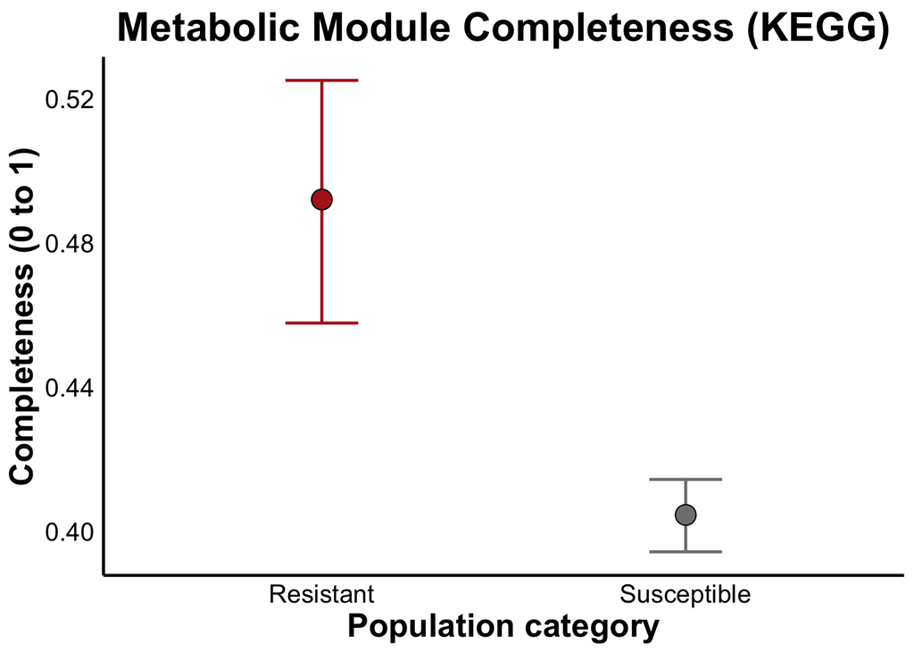

```r
figure_3A <- ggplot(kegg_merged, aes(x = group, y = stepwise_module_completeness, fill = group)) +
  # Add error bars (95% CI using bootstrapping), colored by group
  stat_summary(aes(color = group), fun.data = mean_cl_boot, geom = "errorbar", width = 0.2, size = 0.8) +
  # Add mean points, colored by group
  stat_summary(aes(fill = group), fun = mean, geom = "point", size = 5, shape = 21, color = "black") +
  # Labels & theme
  labs(title = "Metabolic Module Completeness (KEGG)",
       x = "Population category",
       y = "Completeness (0 to 1)") +
  scale_color_manual(values = c("susceptible" = "#808080", "resistant" = "#B22222")) +
  scale_fill_manual(values = c("susceptible" = "#808080", "resistant" = "#B22222")) +
  scale_x_discrete(labels = c("resistant" = "Resistant", "susceptible" = "Susceptible")) +
  #scale_y_continuous(limits = c(0.35, 0.75)) +  # Ensure full Y-axis from 0 to 1
  theme_minimal() +
  theme(
    plot.title = element_text(hjust = 0.5, vjust = 0.8, size = 22, face = "bold"),
    axis.line = element_line(size = 0.8),
    axis.title = element_text(size = 18, face = "bold"),
    axis.text.y = element_text(size = 14, color = "black"),
    axis.text.x = element_text(size = 14, color = "black"),
    legend.position = "none",
    panel.grid.major = element_blank(),
    panel.grid.minor = element_blank()
  )

print(figure_3A)
```

```r
# save
ggsave(filename = "../R output/Figures/Figure_3A_KEGGcompleteness.jpg", plot = figure_3A, width = 7, height = 7, dpi = 300, units = "in")
```

Metabolic module completeness of resistant (red) and susceptible (gray) populations. Mean completeness (±95% CI) is higher in resistant populations (p < 0.001, Wilcoxon test), indicating functional differentiation in the metabolic niche space.

For resistant populations, run PCoA of overrepresented KEGG modules related to energy and amino acid metabolism as they emerge as key functions overrepresented in resistant populations. The goal here is to assess whether these functional traits are structured by taxonomy (same as Pfam analysis).

```r
# prepare data for PCoA
kegg_pcoa_data <- kegg_merged %>%
  dplyr::filter(group == "resistant", module_category %in% c("Amino acid metabolism", "Energy metabolism")) %>%
  dplyr::select(bin_name, module_name, stepwise_module_completeness) %>%
  pivot_wider(names_from = module_name, values_from = stepwise_module_completeness, values_fill = 0) %>%
  column_to_rownames("bin_name")  # Convert bin names to row names

dist_matrix <- vegdist(kegg_pcoa_data, method = "bray") # Bray-Curtis dissimilarity
pcoa_result <- cmdscale(dist_matrix, k = 2, eig = TRUE) # run PCoA

# convert into df
pcoa_df <- as.data.frame(pcoa_result$points)
colnames(pcoa_df) <- c("PCoA1", "PCoA2")
pcoa_df$bin_name <- rownames(kegg_pcoa_data)

res_phyla <- sig_bins %>% filter(group == "resistant")

# remove redundant rows and keep bin_name & phylum info
phylum_info <- bins_extendedinfo %>%
  dplyr::filter(bin %in% res_phyla$bin_name) %>%
  dplyr::select(bin, t_phylum) %>%
  dplyr::rename(bin_name = bin) %>%
  distinct()

pcoa_df <- left_join(pcoa_df, phylum_info, by = "bin_name") # merge phylum for coloring
```

FigureS3C: PCoA of overrepresented KEGG in resistant populations

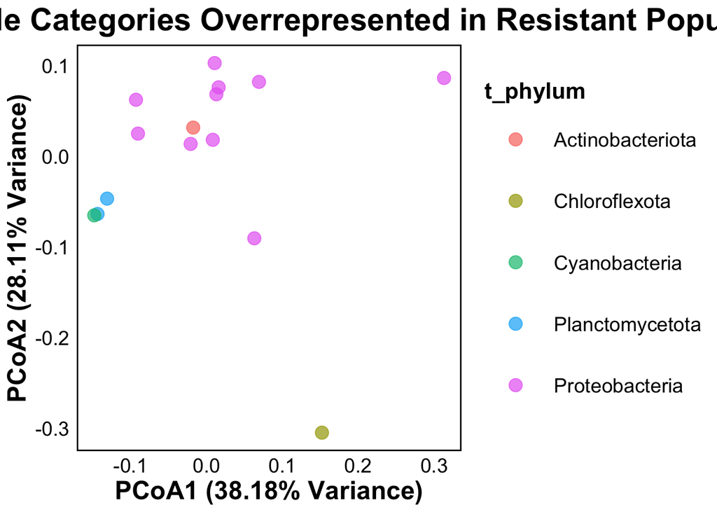

```r
# plot
Figure_S3C <- ggplot(pcoa_df, aes(x = PCoA1, y = PCoA2, color = t_phylum)) +
  geom_point( alpha = 0.7, size = 4) +
  labs(
    title = "PCoA of Key Module Categories Overrepresented in Resistant Populations",
    x = paste0("PCoA1 (", round(pcoa_result$eig[1] / sum(pcoa_result$eig) * 100, 2), "% Variance)"),
    y = paste0("PCoA2 (", round(pcoa_result$eig[2] / sum(pcoa_result$eig) * 100, 2), "% Variance)")
  ) +
  theme_minimal() +
  theme_minimal() +
  theme(
    plot.title = element_text(hjust = 0.5, vjust = 1, face = "bold", size = 22),
    axis.line = element_blank(),
    axis.title = element_text(size = 18, face = "bold"),
    axis.text.y = element_text(size = 14, color = "black"),
    axis.text.x = element_text(size = 14, color = "black"),
    legend.position = "right",
    legend.text = element_text(size = 14),
    legend.title = element_text(size = 16, face = "bold"),
    legend.key.size = unit(3,"line"),
    panel.grid.major = element_blank(),
    panel.grid.minor = element_blank(),
    panel.border = element_rect(colour = "black", fill=NA, size=1)
  )
Figure_S3C
```

```r
# save
ggsave(filename = "../R output/Figures/Figure_S3C_KEGGPCoA_keycategories_taxonomy.jpg", plot = Figure_S3C,width = 13, height = 7, dpi = 300, units = "in")
```

```r
permanova_phylum <- adonis2(dist_matrix ~ t_phylum, data = pcoa_df, permutations = 999, method = "bray") # PERMANOVA based on taxonomy
dispersion_test <- betadisper(dist_matrix, pcoa_df$t_phylum) # taxonomic dispersion test to validate PERMANOVA

# print
anova(dispersion_test)
```

```
## Analysis of Variance Table
##
## Response: Distances
##           Df   Sum Sq   Mean Sq F value  Pr(>F)
## Groups     4 0.078814 0.0197035   3.695 0.04262 *
## Residuals 10 0.053325 0.0053325
## ---
## Signif. codes:  0 '***' 0.001 '**' 0.01 '*' 0.05 '.' 0.1 ' ' 1
```

```r
print(permanova_phylum)
```

```
## Permutation test for adonis under reduced model
## Permutation: free
## Number of permutations: 999
##
## adonis2(formula = dist_matrix ~ t_phylum, data = pcoa_df, permutations = 999, method = "bray")
##          Df SumOfSqs      R2      F Pr(>F)
## Model     4  0.24543 0.45152 2.0581  0.084 .
## Residual 10  0.29813 0.54848
## Total    14  0.54356 1.00000
## ---
## Signif. codes:  0 '***' 0.001 '**' 0.01 '*' 0.05 '.' 0.1 ' ' 1
```

————————————————————-COG analysis——————————————————————–

Prep COG data

```r
pfam <- read.delim("~/Documents/UMich/DataAnalysis/metagenomics_run/pfam/function.txt") # load data

# filter COG data
filtered_cog <- pfam %>%
  filter(source %in% c("COG20_CATEGORY", "COG20_PATHWAY"))
gene.calls.txt <- read.delim("~/Documents/UMich/DataAnalysis/metagenomics_run/gene-calls-txt") # read gene calls

# combine contig info
tmp <- gene.calls.txt %>%
  dplyr::select(gene_callers_id, contig)
cog_summary <- inner_join(filtered_cog, tmp, by = "gene_callers_id")

cog_summary <- cog_summary %>% mutate(bin = str_extract(contig, "^[^-]+")) # extract bin info from contig info

# filter MAGs
cog_MAGs <- cog_summary %>%
  dplyr::filter(str_detect(bin, "_MAG_")) %>%
  dplyr::rename(bin_name = bin)
merged_cog <- inner_join(cog_MAGs, sig_bins, by = "bin_name") # merge cog summary with bin coverage change significance

# split COG category and pathway results into 2 dfs.
df_cog_category <- merged_cog %>%
  filter(source == "COG20_CATEGORY")
df_cog_pathway <- merged_cog %>%
  filter(source == "COG20_PATHWAY")

# split function and accession cols (basically remove !!!)
# define a function to split and expand based on '!!!' delimiter
expand_rows <- function(df, split_columns) {
  # Split the specified columns
  split_df <- df %>%
    mutate(across(all_of(split_columns), ~strsplit(as.character(.), "!!!", fixed = TRUE))) %>%
    # Expand the data frame so that each list element gets its own row
    unnest(cols = all_of(split_columns))

  return(split_df)
}

# apply the function to the cog category df
expanded_df_cog <- expand_rows(df_cog_category, c("accession", "function."))

# save this df
write.csv(expanded_df_cog, "~/Documents/UMich/papers/GrowthDefenseTradeOff/R output/expanded_df_cog.csv")
```

```r
# count occurrences
cog_category_counts <- expanded_df_cog %>%
  group_by(group, function.) %>%
  summarise(count = n(), .groups = "drop") %>%
  pivot_wider(names_from = group, values_from = count, values_fill = 0)

# count unique MAGs in each group
unique_mags_per_group <- expanded_df_cog %>%
  group_by(group) %>%
  summarise(unique_MAGs = n_distinct(bin_name))

# normalize the number of MAGs in each group
cog_category_counts <- cog_category_counts %>%
  mutate(
    decrease_norm = susceptible / unique_mags_per_group$unique_MAGs[unique_mags_per_group$group == "susceptible"],
    increase_norm = resistant / unique_mags_per_group$unique_MAGs[unique_mags_per_group$group == "resistant"]
  )

# calculate fold change (resistant/susceptible)
cog_category_counts <- cog_category_counts %>%
  mutate(fold_change = decrease_norm / increase_norm) %>%
  arrange(desc(fold_change))

print(cog_category_counts)
```

```
## # A tibble: 25 × 6
##    function.       resistant susceptible decrease_norm increase_norm fold_change
##    <chr>               <int>       <int>         <dbl>         <dbl>       <dbl>
##  1 Cytoskeleton           45         608          4.54           3         1.51
##  2 Cell wall/memb…      2315       25602        191.           154.        1.24
##  3 Cell cycle con…       512        5149         38.4           34.1       1.13
##  4 Function unkno…      1110       10859         81.0           74         1.10
##  5 Posttranslatio…      1854       17780        133.           124.        1.07
##  6 Inorganic ion …      1569       14845        111.           105.        1.06
##  7 Signal transdu…      1588       14991        112.           106.        1.06
##  8 Nucleotide tra…       983        8912         66.5           65.5       1.01
##  9 Translation, r…      2842       25345        189.           189.        0.998
## 10 Replication, r…      1463       12766         95.3           97.5       0.977
## # ℹ 15 more rows
```

Calculate COG proportions

```r
# count total COG per MAG
total_cogs_per_mag <- expanded_df_cog %>%
  group_by(bin_name) %>%
  summarise(total_cogs = n(), .groups = "drop")

# count occurrences of each COG category per MAG
cog_counts_per_mag <- expanded_df_cog %>%
  group_by(bin_name, function.) %>%
  summarise(count = n(), .groups = "drop")

# merge dfs to get proportion of each COG per MAG
cog_proportions <- cog_counts_per_mag %>%
  left_join(total_cogs_per_mag, by = "bin_name") %>%
  mutate(proportion = count / total_cogs)

# identify COGs shared between both groups
shared_cogs <- expanded_df_cog %>%
  group_by(function., group) %>%
  summarise(count = n(), .groups = "drop") %>%
  pivot_wider(names_from = group, values_from = count, values_fill = 0) %>%
  filter(susceptible > 0 & resistant > 0) %>%  # Keep only COGs found in both groups
  pull(function.)

# filter proportions to only shared COGs
cog_proportions_shared <- cog_proportions %>%
  filter(function. %in% shared_cogs)

# add group information
cog_proportions_shared <- expanded_df_cog %>%
  dplyr::select(bin_name, group) %>%
  distinct() %>%
  inner_join(cog_proportions_shared, by = "bin_name")

# compute mean proportion for each shared COG function
cog_proportion_summary <- cog_proportions_shared %>%
  dplyr::group_by(function., group) %>%
  dplyr::summarise(mean_proportion = mean(proportion, na.rm = TRUE), .groups = "drop") %>%
  pivot_wider(names_from = group, values_from = mean_proportion, values_fill = 0, names_prefix = "mean_")

# Wilcoxon Rank-Sum test for each shared COG
wilcox_test_results_cog <- cog_proportions_shared %>%
  dplyr::group_by(function.) %>%
  dplyr::summarise(
    p_value = wilcox.test(proportion[group == "susceptible"], proportion[group == "resistant"])$p.value,
    .groups = "drop"
  ) %>%
  dplyr::filter(p_value < 0.05)  # Keep only significantly different COGs

# merge only significant COGs
final_results_cog <- wilcox_test_results_cog %>%
  left_join(cog_proportion_summary, by = "function.")

# view final results with correct number of rows
print(final_results_cog)
```

```
## # A tibble: 8 × 4
##   function.                              p_value mean_resistant mean_susceptible
##   <chr>                                    <dbl>          <dbl>            <dbl>
## 1 Amino acid transport and metabolism    7.46e-4        0.0957           0.0778
## 2 Cell cycle control, cell division, ch… 3.07e-2        0.0159           0.0183
## 3 Cell wall/membrane/envelope biogenesis 3.54e-5        0.0663           0.0914
## 4 Coenzyme transport and metabolism      4.85e-3        0.0676           0.0592
## 5 Energy production and conversion       2.15e-5        0.0799           0.0632
## 6 Function unknown                       1.58e-2        0.0302           0.0375
## 7 Mobilome: prophages, transposons       5.16e-3        0.00888          0.00413
## 8 Posttranslational modification, prote… 1.52e-3        0.0537           0.0625
```

```r
# save
write.csv(cog_proportions_shared, "../R output/cog_proportions_shared.csv")
write.csv(final_results_cog, "../R output/final_results_cog.csv")
```

Figure 3B showing common KEGG modules and COG functions enriched. First prepare data.

```r
# compute mean KEGG module completeness per function
kegg_summary <- kegg_merged %>%
  dplyr::filter(module_class == "Pathway modules") %>%
  dplyr::group_by(module_category, group) %>%
  dplyr::summarise(mean_completeness = mean(stepwise_module_completeness, na.rm = TRUE), .groups = "drop")

# select relevant KEGG categories
selected_kegg <- kegg_summary %>%
  dplyr::filter(module_category %in% c("Amino acid metabolism", "Energy metabolism")) %>%
  dplyr::rename(Module_Category_KEGG = module_category,
         Mean_Completeness = mean_completeness,
         Population_Category = group)

# select relevant COG categories
selected_cog <- final_results_cog %>%
  dplyr::filter(function. %in% c("Amino acid transport and metabolism", "Energy production and conversion")) %>%
  dplyr::rename(COG_Category = function.) %>%
  pivot_longer(cols = starts_with("mean_"), names_to = "Population_Category", values_to = "Mean_Proportion") %>%
  dplyr::mutate(Population_Category = ifelse(Population_Category == "mean_resistant", "resistant", "susceptible"))

# combine KEGG & COG into a single dataframe
combined_kegg_cog <- bind_rows(
  selected_kegg %>% dplyr::mutate(Source = "KEGG"),
  selected_cog %>% dplyr::rename(Module_Category_KEGG = COG_Category) %>% mutate(Source = "COG")
)

# pivot data for proper faceting
df_long_combined <- combined_kegg_cog %>%
  pivot_longer(cols = c(Mean_Completeness, Mean_Proportion),
               names_to = "Metric",
               values_to = "Enrichment_Score") %>%
  dplyr::filter((Source == "KEGG" & Metric == "Mean_Completeness") |
         (Source == "COG" & Metric == "Mean_Proportion")) %>%
  dplyr::mutate(Module_Category_Facet = case_when(
    Source == "KEGG" & Module_Category_KEGG == "Amino acid metabolism" ~ "Amino Acid Metabolism",
    Source == "KEGG" & Module_Category_KEGG == "Energy metabolism" ~ "Energy Metabolism",
    Source == "COG" & Module_Category_KEGG == "Amino acid transport and metabolism" ~ "Amino Acid\nTransport & Metabolism",
    Source == "COG" & Module_Category_KEGG == "Energy production and conversion" ~ "Energy\nProduction & Conversion",
    TRUE ~ NA_character_  # Drop rows that don't belong in the respective facet
  )) %>%
  drop_na(Module_Category_Facet) %>%  # Remove unwanted rows
  dplyr::mutate(Module_Category_Facet = factor(Module_Category_Facet, levels = unique(Module_Category_Facet)))  # Ensure correct factor ordering
```

Make the figure.

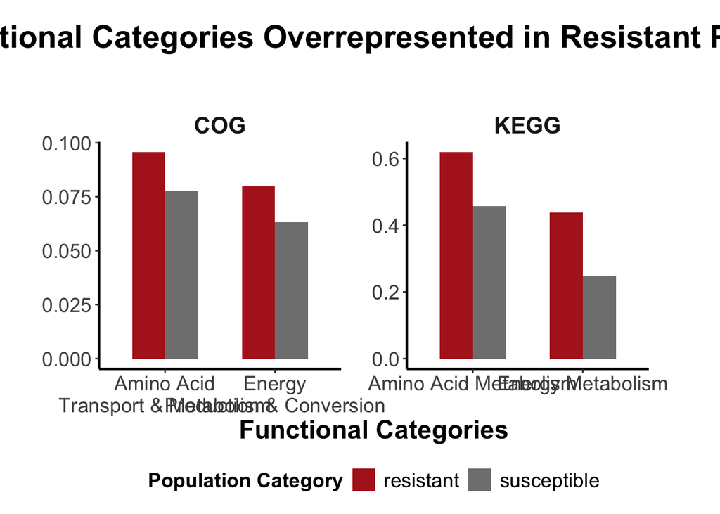

```r
# generate faceted bar plot with correctly filtered x-axis labels
figure_3B <- ggplot(df_long_combined, aes(x = Module_Category_Facet,
                                 y = Enrichment_Score,
                                 fill = Population_Category)) +
  geom_bar(stat = "identity", position = "dodge", width = 0.6) +
  facet_wrap(~ Source, scales = "free",
             labeller = labeller(Source = c("KEGG", "COG"))) +
  labs(title = "Key Functional Categories Overrepresented in Resistant Populations",
       y = "",
       x = "Functional Categories",
       fill = "Population Category") +
  scale_fill_manual(values = c("susceptible" = "#808080", "resistant" = "#B22222")) +
  theme(
    plot.title = element_text(hjust = 0.5, vjust = 8, face = "bold", size = 22),
    plot.margin = ggplot2::margin(50, 50, 10, 10),
    axis.title = element_text(size = 18, face = "bold"),
    axis.text.y = element_text(size = 14),
    axis.text.x = element_text(size = 14),
    axis.line = element_line(size = 0.8),
    legend.position = "bottom",
    legend.text = element_text(size = 14),
    legend.title = element_text(size = 14, face = "bold"),
    strip.text = element_text(size = 16, face = "bold"),
    panel.spacing = unit(1.5, "lines"),
    panel.grid.major = element_blank(),
    panel.grid.minor = element_blank(),
    strip.background = element_blank(),
    panel.background = element_rect(fill = "white")
  )

# print and save
print(figure_3B)
```

```r
ggsave(filename = "../R output/Figures/Figure_3B_KEGG_COG_diffAbundance.jpg",
       plot = figure_3B, width = 14, height = 7, dpi = 600, units = "in")
```

Supplemental plot (S3A) for all overrepresented KEGG categories

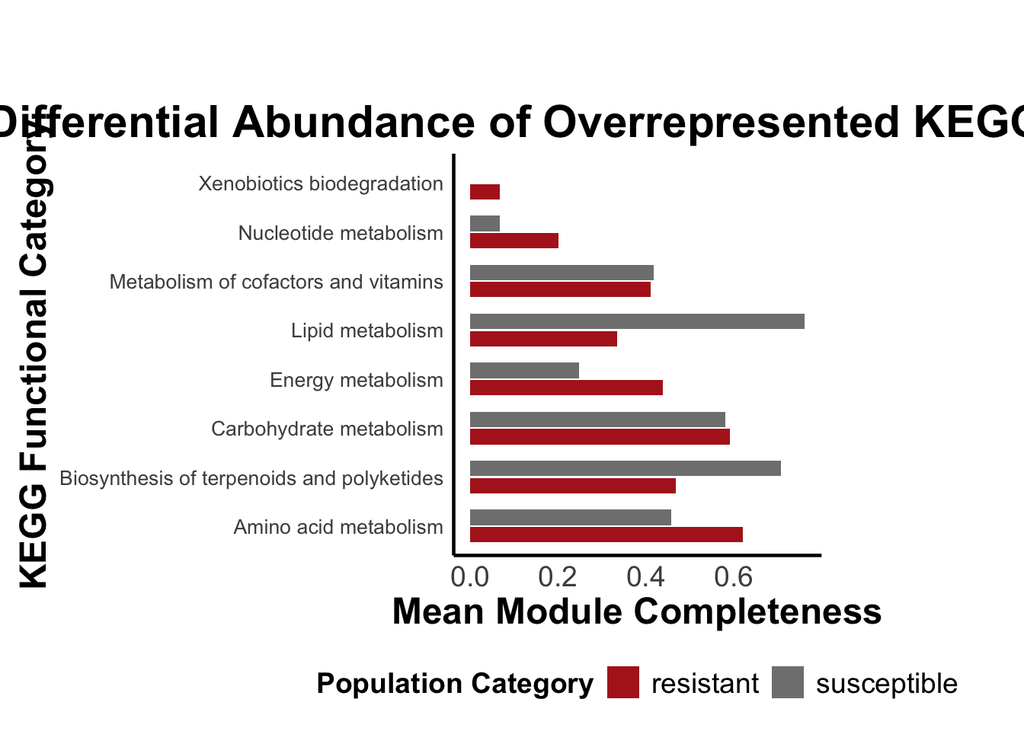

```r
# define custom colors for population categories
custom_colors <- c("resistant" = "#B22222", "susceptible" = "#808080")

# create KEGG enrichment plot
Figure_S3A <- ggplot(kegg_summary, aes(x = mean_completeness, y = module_category, fill = group)) +
  geom_bar(stat = "identity", position = position_dodge2(width = 0.2, preserve = "single"), width = 0.7) +
  scale_fill_manual(values = custom_colors, name = "Population Category") +
  labs(
    title = "Differential Abundance of Overrepresented KEGG Categories",
    x = "Mean Module Completeness",
    y = "KEGG Functional Category"
  ) +
  theme_minimal() +
  theme(
    plot.title = element_text(hjust = 0.5, vjust = 0.6, face = "bold", size = 22),
    plot.margin = ggplot2::margin(50, 100, 10, 10),
    axis.title = element_text(size = 18, face = "bold"),
    axis.text.y = element_text(size = 10),
    axis.text.x = element_text(size = 14),
    axis.line = element_line(size = 0.8),
    legend.position = "bottom",
    legend.text = element_text(size = 14),
    legend.title = element_text(size = 14, face = "bold"),
    strip.text = element_blank(),
    panel.grid.major = element_blank(),
    panel.grid.minor = element_blank()
  )

# save the KEGG plot
ggsave(filename = "../R output/Figures/Figure_S3A_allKEGG_enriched.jpg",
       plot = Figure_S3A,
       width = 15, height = 10, dpi = 300, units = "in")

# print the plot
print(Figure_S3A)
```

Next, similar supplemental plot for COGs.

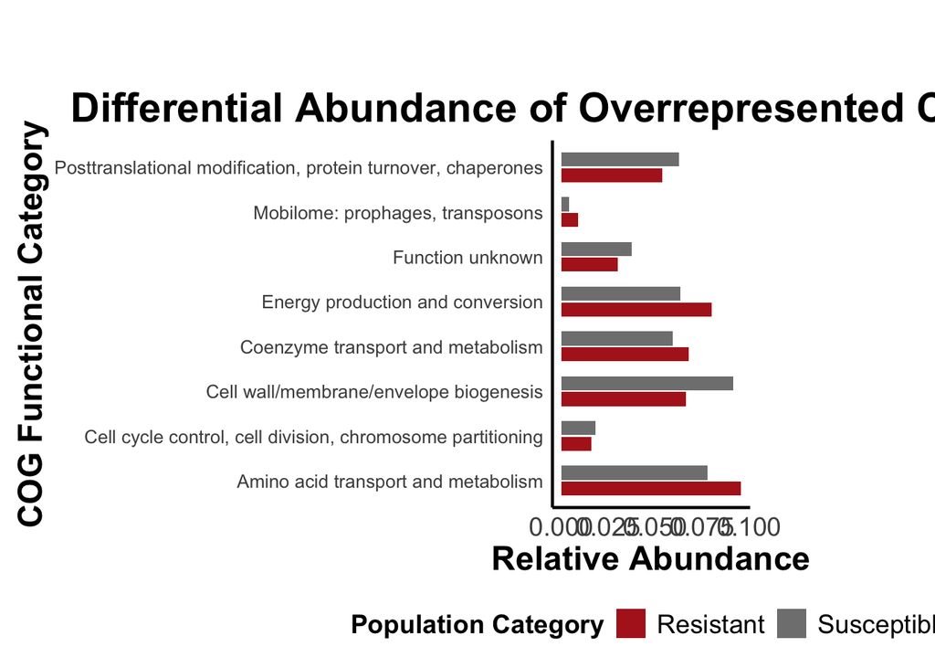

```r
# long format
long_format_cog <- final_results_cog %>%
  pivot_longer(cols = c(mean_resistant, mean_susceptible),
               names_to = "group",
               values_to = "mean_proportion") %>%
  dplyr::select(function., group, mean_proportion) %>%
  dplyr::rename(cog_category = function., population_category = group)

# replace labels
long_format_cog <- long_format_cog %>%
  dplyr::mutate(population_category = case_when(population_category == "mean_resistant" ~ "Resistant",
                                         population_category == "mean_susceptible" ~ "Susceptible")
  )

custom_colors <- c("Resistant" = "#B22222", "Susceptible" = "#808080")

# enrichment plot
Figure_S3B <- ggplot(long_format_cog, aes(x = mean_proportion, y = cog_category, fill = population_category)) +
  geom_bar(stat = "identity", position = position_dodge2(width = 0.2, preserve = "single"), width = 0.7) +
  geom_bar(stat = "identity", position = position_dodge2(width = 0.2, preserve = "single"), width = 0.7) +
  scale_fill_manual(values = custom_colors, name = "Population Category") +
  labs(
    title = "Differential Abundance of Overrepresented COG Categories",
    x = "Relative Abundance",
    y = "COG Functional Category"
  ) +
  theme_minimal() +
  theme(
    plot.title = element_text(hjust = 0.5, vjust = 1, face = "bold", size = 22),
    plot.margin = ggplot2::margin(50, 100, 10, 10),
    axis.title = element_text(size = 18, face = "bold"),
    axis.text.y = element_text(size = 10),
    axis.text.x = element_text(size = 14),
    axis.line = element_line(size = 0.8),
    legend.position = "bottom",
    legend.text = element_text(size = 14),
    legend.title = element_text(size = 14, face = "bold"),
    strip.text = element_blank(),
    panel.grid.major = element_blank(),
    panel.grid.minor = element_blank()
  )

# save the COG plot
ggsave(filename = "../R output/Figures/Figure_S3B_Enriched_COG.jpg",
       plot = Figure_S3B,
       width = 15, height = 10, dpi = 300, units = "in")

# Print the plot
print(Figure_S3B)
```